# scATAC annotation level 4 with KNN

Paula Soler-Vila & Ramon Massoni-Badosa

21 July 2021

# 1 Introduction

Here, we will apply a k-nearest neighbor (KNN) algorithm to classify the scATAC cells to a given cell type category with the help of our training set, the Multiome experiment. Remember, that KNN works on a basic assumption that data points of similar categories are closer to each other.

# 2 Pre-processing

## 2.1 Load packages

```r
library(Seurat)
library(Signac)
library(flexclust)
library(tidyverse)
library(plyr)
library(harmony)
library(class)
library(ggplot2)
library(reshape2)

set.seed(222)
```

## 2.2 Parameters

```r
cell_type = "PC"

# Paths
path_to_obj <- str_c(
  here::here("scATAC-seq/results/R_objects/level_4/"),
  cell_type,
  "/",
  cell_type,
  "_integrated_level_4.rds",
  sep = ""
)

path_to_obj_RNA <- str_c(
  here::here("scRNA-seq/3-clustering/5-level_5/"),
  cell_type,
    "/",
  cell_type,
  "_subseted_integrated_level_5.rds",
  sep = ""
)

path_to_save <- str_c(
  here::here("scATAC-seq/results/R_objects/level_4/"),
  cell_type,
    "/",
  cell_type,
  "_annotated_level_4.rds",
  sep = ""
)
```

## 2.3 Variables

```r
reduction <- "harmony"
dims <- 1:40
color_palette<- c("black", "gray", "red", "yellow", "violet",
                  "green4","blue", "chocolate1", "coral2",
                  "blueviolet","brown1", "darkmagenta",
                  "deepskyblue1", "dimgray", "deeppink1",
                  "green", "lightgray", "hotpink1",
                  "indianred4", "khaki", "mediumorchid2")
```

## 2.4 Load data

We need to load the scRNAseq annotation from Multiome experiment (cell barcode and cell-type assigned) and the integrated scATAC data.

```r
seurat_RNA <- readRDS(path_to_obj_RNA)

PC_subtypes <- c("GC Derived precursor 2",
                 "Proliferating plasmablast",
                 "GC Derived precursor 1",
                 "IgM",
                 "GC Derived precursor 3",
                 "IgG mature",
                 "IgA mature",
                 "IgG plasmablast",
                 "IgD",
                 "GC Derived precursor 0")


tonsil_RNA_annotation <- seurat_RNA@meta.data %>%
  dplyr::filter(assay == "multiome") %>%
  dplyr::filter(annotation_level_5 %in% PC_subtypes ) %>%
  dplyr::select("barcode", "annotation_level_5")

colnames(tonsil_RNA_annotation) <- c("cell_barcode",
                                     "annotation_level_5")
```

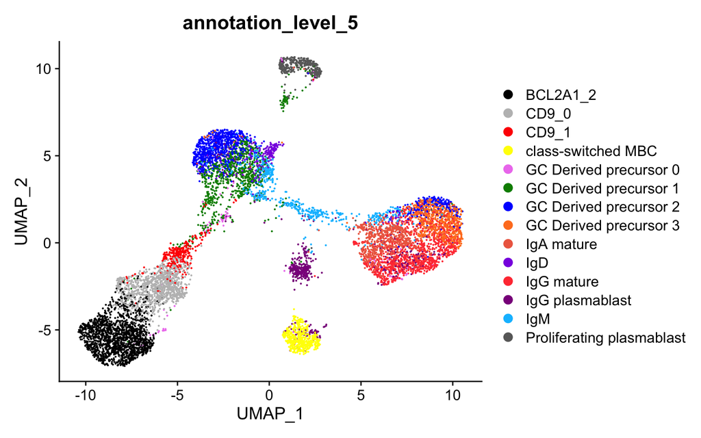

```r
DimPlot(seurat_RNA,
  group.by = "annotation_level_5",
  cols = color_palette,
  pt.size = 0.1)
```

```r
seurat_ATAC <- readRDS(path_to_obj)
seurat_ATAC
```

```
## An object of class Seurat
## 270784 features across 1932 samples within 1 assay
## Active assay: peaks_macs (270784 features, 115146 variable features)
##  3 dimensional reductions calculated: umap, lsi, harmony
```

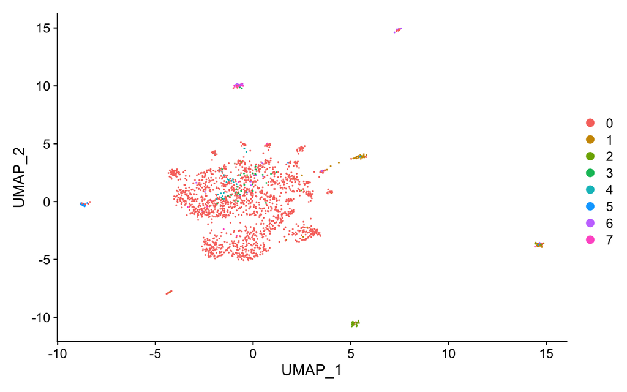

```r
p1 <- DimPlot(seurat_ATAC,
  pt.size = 0.1)
p1
```

Annotation level 5 for scATAC will be defined “a priori” as unannotated and the scRNA annotation will be transfered to the scATAC-multiome cells based on the same cell barcode.

```r
tonsil_scATAC_df <- data.frame(cell_barcode = colnames(seurat_ATAC)[seurat_ATAC$assay == "scATAC"])
tonsil_scATAC_df$annotation_level_5 <- "unannotated"

df_all <- rbind(tonsil_RNA_annotation,tonsil_scATAC_df)
rownames(df_all) <- df_all$cell_barcode
df_all <- df_all[colnames(seurat_ATAC), ]

seurat_ATAC$annotation_level_5 <- df_all$annotation_level_5
seurat_ATAC@meta.data$annotation_prob  <- 1
melt(table(seurat_ATAC$annotation_level_5))
```

```
##                         Var1 value
## 1     GC Derived precursor 0     6
## 2     GC Derived precursor 1   174
## 3     GC Derived precursor 2   147
## 4     GC Derived precursor 3    14
## 5                 IgA mature    28
## 6                        IgD    87
## 7                 IgG mature    31
## 8            IgG plasmablast    25
## 9                        IgM   112
## 10 Proliferating plasmablast    29
## 11               unannotated  1279
```

```r
table(is.na(seurat_ATAC$annotation_level_5))
```

```
##
## FALSE
##  1932
```

## 2.5 General low-dimensionality representation of the assays

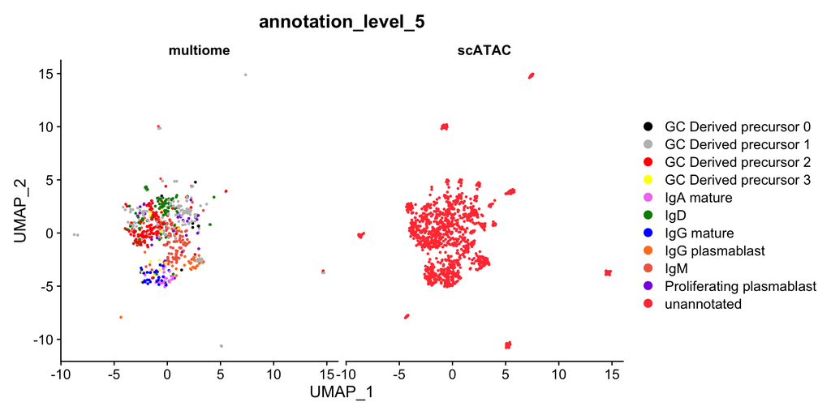

```r
DimPlot(seurat_ATAC,
  group.by = "annotation_level_5",
  split.by = "assay",
  cols = color_palette,
  pt.size = 0.5)
```

# 3 KNN Algorithm

## 3.1 Data Splicing

Data splicing basically involves splitting the data set into training and testing data set.

```r
reference_cells <- colnames(seurat_ATAC)[seurat_ATAC$assay == "multiome"]
query_cells <- colnames(seurat_ATAC)[seurat_ATAC$assay == "scATAC"]

reduction_ref <- seurat_ATAC@reductions[[reduction]]@cell.embeddings[reference_cells, dims]
reduction_query <- seurat_ATAC@reductions[[reduction]]@cell.embeddings[query_cells, dims]
```

## 3.2 Cross-validation of the K parameter.

We’re going to calculate the number of observations in the training dataset that correspond to the Multiome data. The reason we’re doing this is that we want to initialize the value of ‘K’ in the KNN model. To do that, we split our training data in two part: a train.loan, that correspond to the random selection of the 70% of the training data and the test.loan, that is the remaining 30% of the data set. The first one is used to traint the system while the second is uses to evaluate the learned system.

```r
dat.d <- sample(1:nrow(reduction_ref),
               size=nrow(reduction_ref)*0.7,replace = FALSE)

train.loan  <- reduction_ref[dat.d,] # 70% training data
test.loan <- reduction_ref[-dat.d,] # remaining 30% test data

train.loan_labels <- seurat_ATAC@meta.data[row.names(train.loan),]$annotation_level_5
test.loan_labels <- seurat_ATAC@meta.data[row.names(test.loan),]$annotation_level_5

k.optm <- c()
k.values <- c()

for (i in c(seq(1,10),16,32,64,128)) {
 print(i)
 knn.mod <- knn(train=train.loan, test=test.loan, cl=train.loan_labels, k=i)
 k.optm <- c(k.optm, 100 * sum(test.loan_labels == knn.mod)/NROW(test.loan_labels))
 k.values <- c(k.values,i)
}
```

```
## [1] 1
## [1] 2
## [1] 3
## [1] 4
## [1] 5
## [1] 6
## [1] 7
## [1] 8
## [1] 9
## [1] 10
## [1] 16
## [1] 32
## [1] 64
## [1] 128
```

Now we can plot the accuracy of the model taking in account a range of different K and select the best one.

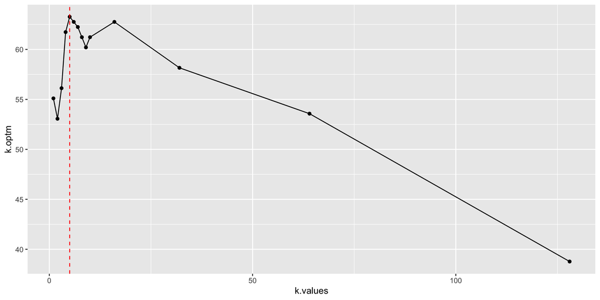

```r
k.optim = data.frame(k.values,k.optm)

p3 <- ggplot(data=k.optim, aes(x=k.values, y=k.optm, group=1)) +
 geom_line() +
 geom_point() +
 geom_vline(xintercept=5, linetype="dashed", color = "red")

p3
```

## 3.3 Building a Machine Learning model with the optimal k value.

```r
train.loan  <- reduction_ref
test.loan <- reduction_query

train.loan_labels <- seurat_ATAC@meta.data[row.names(train.loan),]$annotation_level_5
test.loan_labels <- seurat_ATAC@meta.data[row.names(test.loan),]$annotation_level_5

knn.mod <- knn(train=train.loan,
               test=test.loan,
               cl=train.loan_labels,
               k=5,
               prob=T)

annotation_data <- data.frame(query_cells, knn.mod, attr(knn.mod,"prob"))
colnames(annotation_data) <- c("query_cells",
                               "annotation_level_5",
                               "annotation_prob")

annotation_data$annotation_level_5 <- as.character(annotation_data$annotation_level_5)
seurat_ATAC@meta.data[annotation_data$query_cells,]$annotation_level_5 <- annotation_data$annotation_level_5
seurat_ATAC@meta.data[annotation_data$query_cells,]$annotation_prob <- annotation_data$annotation_prob
seurat_ATAC$annotation_level_5 <- factor(seurat_ATAC$annotation_level_5)
```

## 3.4 Low-dimensionality representation of the assays

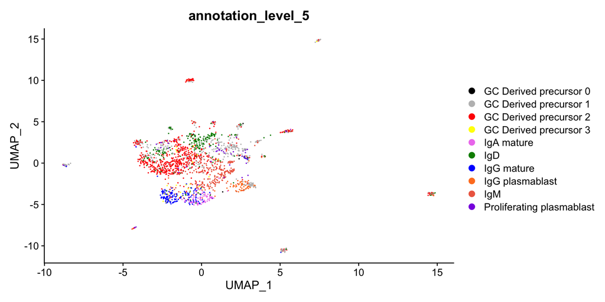

```r
DimPlot(
  seurat_ATAC,
  cols = color_palette,
  group.by = "annotation_level_5",
  pt.size = 0.1)
```

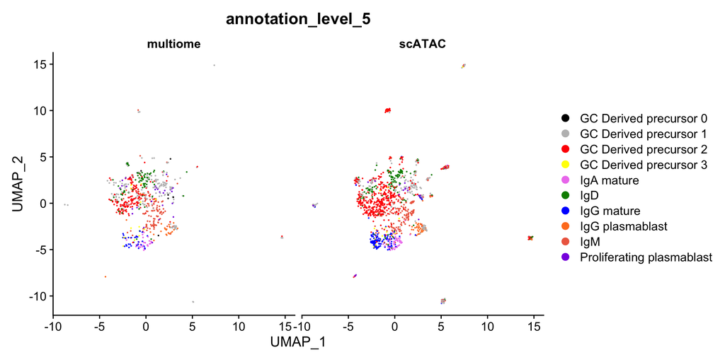

```r
DimPlot(
  cols = color_palette,
  seurat_ATAC, reduction = "umap",
  group.by = "annotation_level_5",
  pt.size = 0.1,  split.by = "assay")
```

```r
melt(table(seurat_ATAC$annotation_level_5))
```

```
##                         Var1 value
## 1     GC Derived precursor 0     7
## 2     GC Derived precursor 1   410
## 3     GC Derived precursor 2   589
## 4     GC Derived precursor 3    30
## 5                 IgA mature    95
## 6                        IgD   227
## 7                 IgG mature   152
## 8            IgG plasmablast    72
## 9                        IgM   292
## 10 Proliferating plasmablast    58
```

```r
saveRDS(seurat_ATAC, path_to_save)
```

## 3.5 Low-dimensionality representation of the prediction probability

Note that the probability of the prediction was lower in the transitioning cells and in not-defined clusters.

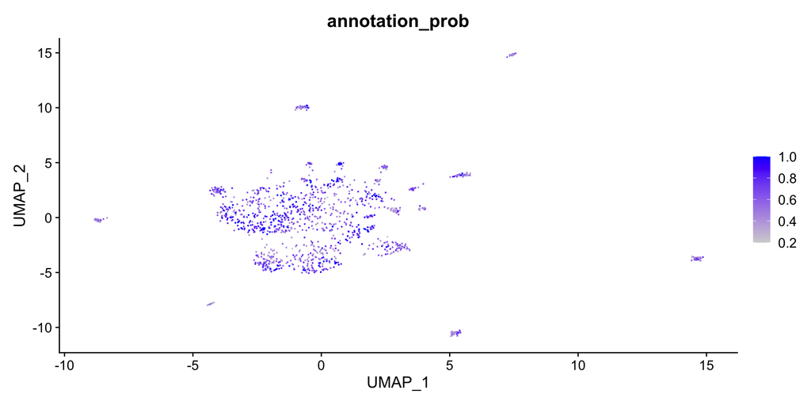

```r
seurat_ATAC_scATAC = subset(seurat_ATAC, assay == "scATAC")

FeaturePlot(
  seurat_ATAC_scATAC, reduction = "umap",
  features = "annotation_prob",
  pt.size = 0.1)
```